# 3 Corticoides

Os corticosteroides são agentes terapêuticos de importância fundamental na medicina moderna. Seu uso clínico abrange uma vasta gama de condições, principalmente no tratamento de **distúrbios inflamatórios e alérgicos**, bem como em doenças que exigem a **supressão de ações indesejadas ou inapropriadas do sistema imunológico**. Clinicamente, o termo “corticosteroide” é usado para descrever agentes com atividade glicocorticoide, tendo o cortisol como o principal glicocorticoide endógeno. Devido aos seus potentes e abrangentes efeitos anti-inflamatórios e imunossupressores, essas terapias podem ser cruciais para o manejo de doenças agudas e crônicas.

O mecanismo de ação que confere essa eficácia é um processo molecular complexo que ocorre no núcleo de numerosas células. Diferente de muitos fármacos que atuam em receptores de superfície, a molécula de esteroide, lipofílica, difunde-se através da membrana celular e liga-se a receptores de glicocorticoides (GR) localizados no citoplasma. Essa ligação induz uma mudança conformacional no receptor, permitindo que o complexo receptor-fármaco se transloque para o núcleo.

Uma vez no núcleo, o complexo dimeriza e interage com o DNA em sítios específicos chamados elementos de resposta a glicocorticoides (GREs). É essa interação com os genes que fundamenta seus efeitos farmacológicos, operando por dois caminhos principais:

Transativação (+GRE): O complexo receptor-esteroide liga-se aos GREs para aumentar a transcrição de genes que codificam mediadores anti-inflamatórios, como a anexina A1 (ou lipocortina).

Transrepressão (-GRE): De forma mais crítica para a inflamação, o complexo suprime a transcrição de genes que codificam mediadores pró-inflamatórios, inibindo a síntese de citocinas (como TNF-alfa e interleucinas), quimiocinas e enzimas como a ciclooxigenase-2 (COX-2).

Apesar da sua notável eficácia, o uso de corticosteroides em doses farmacológicas—aquelas necessárias para suprimir a inflamação—está intrinsecamente ligado a uma miríade de efeitos adversos. Esses efeitos colaterais são, em essência, uma extensão de sua própria atividade glicocorticoide excessiva, afetando quase todos os sistemas orgânicos e processos metabólicos do corpo.

O mecanismo molecular desses efeitos adversos é multifacetado. Primeiramente, a **supressão do eixo hipotálamo-pituitária-adrenal (HPA)** é o efeito adverso mais significativo do uso prolongado (definido como >2 semanas). A administração exógena contínua de glicocorticoides inibe a produção endógena de cortisol por feedback negativo, um estado de supressão que pode exigir meses para ser revertido após a interrupção da terapia. A HPA é relevante pois a interrupção abrupta do tratamento com glicocorticoides pode precipitar uma crise adrenal aguda, uma condição potencialmente fatal. Os sintomas da insuficiência adrenal secundária à retirada de corticosteroides incluem fadiga, fraqueza, hipotensão e, em casos graves, choque adrenal . Estes sintomas resultam da incapacidade das glândulas suprarrenais de produzir cortisol endógeno suficiente após a supressão prolongada pelo tratamento exógeno.

Em segundo lugar, muitos efeitos colaterais são explicados pela origem estrutural comum desses hormônios. Todos os esteroides, incluindo **mineralocorticoides (como a aldosterona)** e **hormônios sexuais**, são derivados da mesma via metabólica do colesterol. As semelhanças estruturais entre eles explicam por que os glicocorticoides sintéticos podem ter atividade mineralocorticoide indesejada, levando à retenção de fluidos e distúrbios eletrolíticos. Além disso, seus efeitos pleiotrópicos sobre o metabolismo de carboidratos (gluconeogênese), proteínas (catabolismo) e lipídios (mobilização de ácidos graxos), bem como sobre o metabolismo ósseo e do cálcio, são responsáveis por toxicidades conhecidas como **hiperglicemia**, **miopatia** e **osteoporose**.

A necessidade de dissociar a potente atividade anti-inflamatória (derivada da transrepressão) dos efeitos adversos metabólicos e mineralocorticoides (parcialmente ligados à transativação e à falta de especificidade do receptor) tornou-se o principal motor para a evolução da química farmacêutica dos corticosteroides.

Este capítulo explorará a Relação Estrutura-Atividade (SAR) desses compostos, detalhando como modificações sintéticas na estrutura base do esteroide permitiram o desenvolvimento de agentes mais seguros e eficazes. Analisaremos como alterações estruturais específicas—como a introdução de halogênios ou duplas ligações—foram usadas para aumentar a potência anti-inflamatória e, crucialmente, minimizar a atividade mineralocorticoide. Discutiremos também como a química farmacêutica possibilitou o desenvolvimento de pró-fármacos (como prednisona e cortisona) que requerem ativação hepática, e o design de análogos sintéticos potentes (como os corticosteroides inalados) com farmacocinética otimizada (maior lipofilicidade, maior afinidade pelo receptor e menor biodisponibilidade sistêmica), uma estratégia desenvolvida especificamente para direcionar a ação local e evitar os efeitos adversos significativos do uso crônico (**antefármacos**).

## 3.1 **O Protótipo Endógeno: Cortisol (Hidrocortisona)**

Para compreender o design racional dos análogos sintéticos de corticosteroides, é imperativo primeiro analisar seu protótipo endógeno: o cortisol (clinicamente conhecido como hidrocortisona). A farmacologia dos análogos sintéticos é, em grande parte, uma resposta direta às limitações fisiológicas e metabólicas do próprio cortisol.

### 3.1.1 Regulação e Efeitos Fisiológicos

O cortisol é o principal hormônio do estresse, essencial para a vida, e regula uma vasta gama de processos fisiológicos, incluindo desenvolvimento, homeostase, metabolismo, cognição e inflamação. Sua síntese e liberação pela glândula adrenal são estritamente controladas pelo eixo Hipotálamo-Pituitária-Adrenal (HPA), que responde a estímulos de estresse e a um ritmo circadiano (resultando em picos de cortisol pela manhã) Figure 3.1.

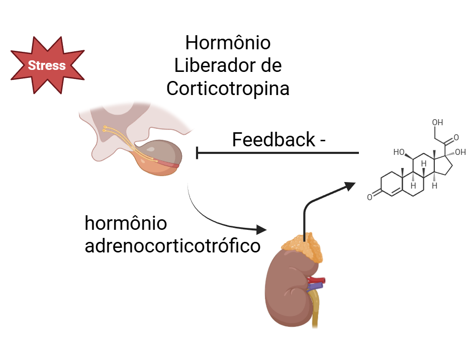

Figure 3.1: Regulação do Eixo Hipotálamo-Pituitária-Adrenal (HPA). Estímulos como o estresse ativam o hipotálamo para liberar o Hormônio Liberador de Corticotropina (CRH). Este hormônio estimula a glândula pituitária (hipófise) a secretar o hormônio adrenocorticotrófico (ACTH). O ACTH, por sua vez, age na glândula adrenal (localizada acima do rim), promovendo a síntese e a liberação de cortisol. O próprio cortisol regula o eixo, exercendo um feedback negativo (Feedback -) sobre o hipotálamo e a pituitária para inibir a liberação de CRH e ACTH, controlando assim sua própria produção.

A liberação de cortisol endógeno não é constante, mas sim controlada pelo eixo hipotálamo-pituitária-adrenal (HPA) em um padrão circadiano e diurno que se repete a cada 24 horas. Esse ritmo é acoplado aos padrões de dia e noite, sendo que em humanos, as concentrações plasmáticas de cortisol atingem seu pico caracteristicamente no início da manhã (por exemplo, entre 6:00 e 8:00) e são mais baixas à noite, durante o sono. Esse perfil de liberação é regulado por estímulos do núcleo supraquiasmático (SCN) no cérebro, que por sua vez estimula o hipotálamo, iniciando a cascata de liberação hormonal que culmina na produção de cortisol pela glândula adrenal.

Os efeitos do cortisol são pleiotrópicos, afetando quase todos os tecidos. Suas ações mais conhecidas—e que são a base tanto de seu uso terapêutico quanto de seus efeitos adversos—incluem:

**Metabolismo**: Promove a gliconeogênese (aumentando a glicose no sangue), o catabolismo proteico (causando fraqueza muscular e afinamento da pele) e a redistribuição de gordura (levando à obesidade central).

**Função Imune**: Exerce potentes efeitos anti-inflamatórios e imunossupressores, que foram explorados farmacologicamente.

**Outros Sistemas**: Afeta o crescimento ósseo, a função cardiovascular, a cognição e o equilíbrio hidroeletrolítico.

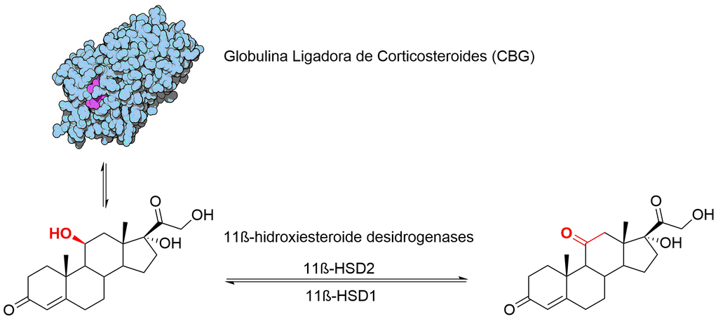

Figure 3.2: Metabolismo do Cortisol e ligação a CBG.

2. **Metabolismo de Ativação/Inativação (11β-HSD)**: A disponibilidade do cortisol no nível celular é rigorosamente controlada por duas enzimas: as 11β-hidroxiesteroide desidrogenases (11β-HSD).

**11β-HSD2**: Esta enzima atua como um “protetor” em tecidos como rins e pâncreas. Ela inativa o cortisol (ativo) convertendo-o em cortisona (inativa). Isso é crucial para permitir que a aldosterona se ligue ao seu receptor mineralocorticoide sem a interferência do cortisol (que está em concentração muito maior).

**11β-HSD1**: Esta enzima faz o oposto. Em tecidos como fígado, tecido adiposo e pulmão, ela ativa a cortisona (inativa) de volta a cortisol (ativo), regenerando o glicocorticoide ativo localmente.

Essa via metabólica de interconversão cortisol/cortisona é um “calcanhar de Aquiles” farmacológico. O cortisol (hidrocortisona) administrado como fármaco é rapidamente inativado pela 11β-HSD2. Para contornar isso, análogos sintéticos (como a dexametasona) foram projetados para não serem substratos da 11β-HSD2. Por outro lado, a química farmacêutica explorou essa via ao criar pró-fármacos, como a prednisona (análogo da cortisona), que precisam ser ativados pela 11β-HSD1 no fígado para se tornarem prednisolona (análogo do cortisol).

Compreender esses efeitos fisiológicos e as complexidades metabólicas do cortisol nos permite analisar, na próxima seção, como modificações estruturais estratégicas levaram à criação de análogos com maior potência anti-inflamatória, menor atividade mineralocorticoide e perfis farmacocinéticos superiores.

## 3.2 Estrutura do cortisol

O núcleo esteroidal do cortisol segue o padrão dos esteroides, chamado ciclopentanoperidrofenantreno, composto por quatro anéis fusionados numerados de 1 a 21, com a numeração partindo do anel A e avançando sequencialmente até o anel D. As ligações duplas e grupos funcionais recebem seu número de acordo com a posição do átomo de carbono, por exemplo: no cortisol, a dupla ligação entre C4 e C5 recebe a denominação “4-ene” $\Delta^4$. Os radicais hidroxila presentes nos carbonos C11, C17 e C21 são indicados na nomenclatura, como no nome IUPAC: 11β,17α,21-trihydroxypregn-4-ene-3,20-dione. Os termos “alfa” (α) e “beta” (β) na nomenclatura apontam para a orientação espacial dos radicais ou funções em relação ao plano do núcleo: “β” indica projeção acima do plano do anel (frontal), enquanto “α” se refere à projeção para baixo do plano (posterior), sendo a hidroxi do C11 um exemplo clássico de posição β no cortisol.

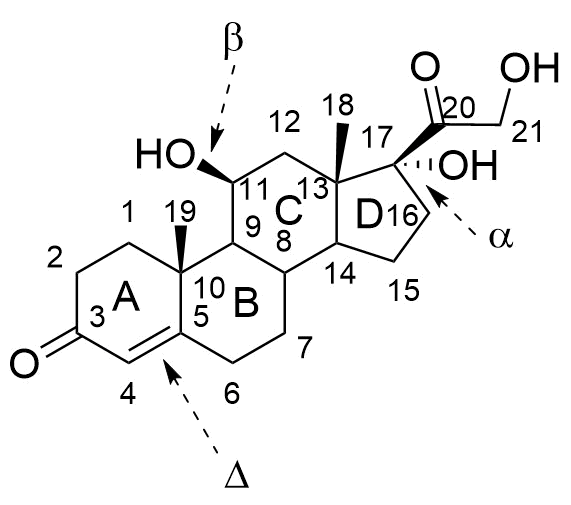

Figure 3.3: Numeração e nomenclatura padronizada para os núcleos esteroidais.

## 3.3 Prednisona e prednisolona

#### 3.3.0.1 O Início da Modificação Sintética: Cortisona e a Prednisona

https://doi.org/10.1016/j.rdc.2015.08.001

A história da química farmacêutica dos corticosteroides começa na década de 1940, em uma busca competitiva para isolar os hormônios do córtex adrenal. Químicos como Edward Kendall e Tadeus Reichstein isolaram dezenas de compostos, sendo os mais promissores o **Composto E (Cortisona)** e o **Composto F (Cortisol)**. Do ponto de vista estrutural, a única diferença entre eles é a natureza do substituinte no Carbono 11 (C-11) como mencionado Figure 3.2.

Em 1948, o reumatologista Philip Hench, que havia postulado a existência de uma “Substância X” capaz de reverter a artrite reumatoide, administrou o Composto E (Cortisona), recém-sintetizado por Lewis Sarett na Merck, a uma paciente (“Sra. G.”) com resultados “milagrosos”. Esse evento, que rendeu o Prêmio Nobel de 1950, marcou o nascimento da corticoterapia.

Contudo, a euforia inicial foi rapidamente substituída pela realidade clínica: os pacientes desenvolviam rapidamente os efeitos adversos que hoje conhecemos. A própria “Sra. G.” tornou-se “grosseiramente cushingóide” e sofreu de depressão e psicose, levando à sua internação em uma ala psiquiátrica. Todos os pacientes originais começaram a experimentar os “temidos efeitos colaterais dos corticosteroides em altas doses prolongadas”.

Quimicamente, o problema era claro: tanto a cortisona (potência mineralo: 0.8) quanto o cortisol (potência mineralo: 1.0) possuíam atividade mineralocorticoide quase tão potente quanto sua atividade glicocorticoide (anti-inflamatória). Isso deu início à primeira grande busca da química farmacêutica de esteroides:

**Dissociar a atividade glicocorticoide (desejada) da atividade mineralocorticoide (indesejada).**

O primeiro grande avanço ocorreu em 1954, nos laboratórios da Schering Corporation. A introdução de uma **dupla ligação entre os carbonos C-1 e C-2** do anel A (um processo de $\Delta^1$-desidrogenação) nos compostos originais (cortisona e cortisol) levou à criação de dois novos análogos Figure 3.5.

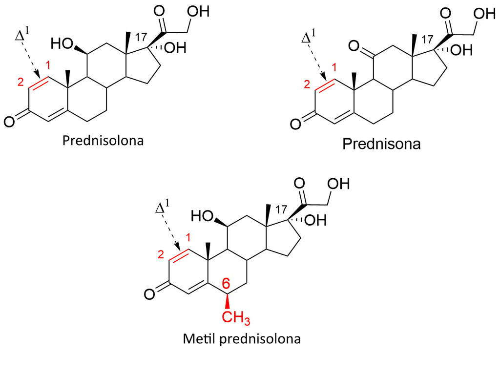

Figure 3.5: Comparação estrutural lado a lado: Prednisona e Prednisolona. A dupla ligação $\Delta^1$ (C-1/C-2) nos análogos. Aumento na potência glicocorticoide (0.8 -> 3.5-5.0) e a leve redução ou manutenção da potência mineralocorticoide (0.8 -> 0.8). Metilpredinisolona tem mais vantagens ainda como maior duração e eficácia glicocorticoide.

Essa única modificação estrutural teve um efeito profundo: aumentou a potência glicocorticoide em **três a cinco vezes** em relação aos compostos originais. Mais importante, essa modificação resultou em *menos efeitos mineralocorticoides*, permitindo o uso de doses significativamente mais baixas para obter o mesmo efeito anti-inflamatório. A busca por moléculas mais seguras e seletivas estava apenas começando, mas a prednisona e a prednisolona se tornaram os fármacos de escolha, substituindo amplamente a cortisona e o cortisol originais na prática clínica.

## 3.4 A Revolução da Potência e Seletividade: Dexametasona

https://doi.org/10.3171/2023.9.jns231099

Enquanto a prednisona representou um avanço incremental, a verdadeira revolução na química dos esteroides ocorreu em 1958. Os pesquisadores, “em esforços intensos para encontrar um composto relacionado com propriedades terapêuticas superiores”, focaram em duas novas modificações estruturais que, quando combinadas, alcançariam o objetivo final de dissociação Figure 3.6.

1. **Fluoração em C-9 ($\alpha$-F):** A introdução de um átomo de flúor na posição 9-alfa do núcleo esteroide. Esta modificação é conhecida por aumentar drasticamente a potência glicocorticoide, mas também, problematicamente, a potência mineralocorticoide como é o caso da fludrocortisona.
2. **Metilação em C-16 ($\alpha$-metil):** A adição de um grupo metil na posição 16-alfa. Esta foi a modificação-chave que, quando combinada com a 9-fluoração, serviu para *anular* quase completamente a atividade mineralocorticoide indesejada.

A combinação destas duas modificações sobre a estrutura da prednisolona ($\Delta^1$) criou o **9$\alpha$-fluoro-16$\alpha$-metilprednisolona**, um novo análogo sintetizado por Glen E. Arth e colegas na Merck, que ficou conhecido como **Dexametasona**.

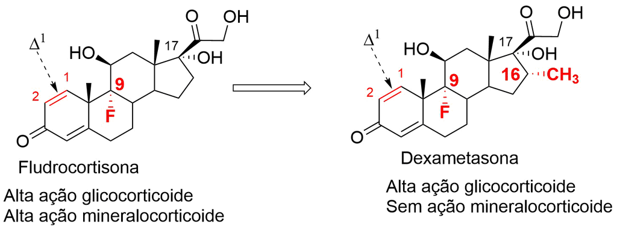

Figure 3.6: A modificação estrutural chave para a seletividade Glico/Mineralocorticoide. A comparação entre a Fludrocortisona (esquerda) e a Dexametasona (direita) ilustra o avanço crucial na Relação Estrutura-Atividade. Ambas as moléculas possuem alta potência glicocorticoide, em parte devido à fluoração na posição C-9 ($\alpha$-F). No entanto, a Fludrocortisona também exibe alta e indesejada ação mineralocorticoide. A introdução estratégica de um grupo metil na posição C-16 (destacado em vermelho) na Dexametasona anula essa atividade, resultando em um fármaco com potente ação anti-inflamatória, mas “Sem ação mineralocorticoide”, alcançando assim a dissociação terapêutica desejada.

O resultado foi uma molécula com um perfil farmacológico sem precedentes:

**Potência Glicocorticoide Extrema:** A potência anti-inflamatória disparou, tornando-se de 25 a 80 vezes mais potente que o cortisol e mais de seis vezes mais potente que a prednisona.

**Atividade Mineralocorticoide Nula:** A modificação 16-alfa-metil atingiu o objetivo final da pesquisa: eliminou efetivamente a atividade mineralocorticoide (potência de 0), eliminando o risco de retenção de fluidos e hipertensão associado aos compostos anteriores.

**Estabilidade Metabólica e Duração:** O grupo 16-alfa-metil também serviu para proteger a molécula das “vias de inativação metabólica”, aumentando sua estabilidade e prolongando sua meia-vida para 36-54 horas, em comparação com as 16-36 horas da prednisona.

Esta combinação de potência extrema, seletividade completa e longa duração de ação fez da dexametasona um fármaco revolucionário. Logo após sua síntese, o neurocirurgião residente Joseph Galicich aplicou este novo composto em pacientes com edema cerebral associado a tumores, observando melhorias drásticas na paresia, redução do desvio da linha média e diminuição da mortalidade. A dexametasona tornou-se, e permanece até hoje, o padrão-ouro para o tratamento do edema cerebral e outras condições inflamatórias agudas graves.

## 3.5 Outros Análogos Notáveis: Triancinolona e Betametasona

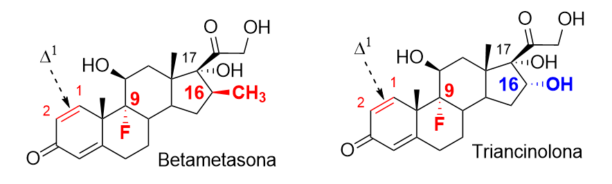

Figure 3.7: Triancinolona e Betametasona

A Betametasona Figure 3.7, por sua vez, é o epímero da dexametasona. Quimicamente, ela é a 16$\beta$-metil-9$\alpha$-fluoroprednisolona. A única diferença estrutural entre as duas é a estereoquímica do grupo metil no C-16 (Beta na betametasona, Alfa na dexametasona). Farmacologicamente, essa pequena inversão espacial não resultou em diferenças clínicas significativas; a betametasona possui o mesmo perfil de potência extrema (Potência G: 25-80) e ausência de atividade mineralocorticoide (Potência M: 0) que a dexametasona. As duas são frequentemente consideradas terapeuticamente equivalentes e usadas de forma intercambiável.

**ImportantCuriosidade: Deflazacort**

O **Deflazacort** representa uma modificação estrutural mais complexa em relação aos análogos anteriores. Quimicamente, é um **derivado oxazolínico da prednisolona**. Assim como a cortisona e a prednisona, o deflazacort é um **pró-fármaco**; após a absorção, ele é rapidamente desacetilado por esterases plasmáticas ao seu metabólito ativo, o 21-hidroxideflazacort. Em termos de potência, o deflazacort é geralmente considerado ligeiramente *menos* potente que a prednisolona em uma base de peso. Estudos clínicos frequentemente utilizaram uma razão de dose de 1.2:1 (mg de deflazacort : mg de prednisolona) para buscar eficácia anti-inflamatória equivalente, embora algumas pesquisas sugiram que razões mais altas (até 1.6:1 ou mesmo >2:1, dependendo do parâmetro avaliado) podem ser necessárias para equipotência real.

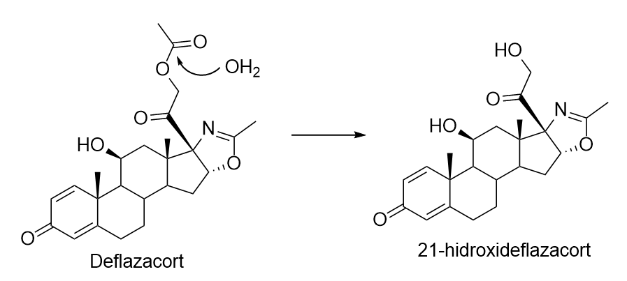

Figure 3.8: Estrutura do deflazacort.

A principal justificativa para o desenvolvimento do deflazacort foi a busca por um perfil de efeitos adversos mais favorável, particularmente em relação ao metabolismo de glicose e ósseo. Algumas evidências, embora inconsistentes e baseadas em estudos menores ou marcadores substitutos, sugeriram que o deflazacort poderia ser menos diabetogênico e causar menor perda óssea em comparação com a prednisolona em doses consideradas equipotentes. No entanto, a controvérsia sobre a real equipotência levanta a possibilidade de que esses benefícios observados possam ser, em parte, uma consequência de uma menor dosagem efetiva de glicocorticoide quando se utiliza a razão de conversão padrão, . Apesar disso, o deflazacort representa um esforço contínuo na modificação estrutural para modular não apenas a potência, mas também o perfil de segurança dos corticosteroides.

### 3.5.1 Bases moleculares da potência, seletividade e duração de ação.

A ausência marcante de atividade mineralocorticoide na dexametasona, apesar de sua alta potência, resulta de uma interação complexa entre suas modificações estruturais e as interações com os receptores. Embora o grupo 9α-fluoro aumente intrinsecamente a potência tanto nos receptores glicocorticoides (GR) quanto nos mineralocorticoides (MR), em parte por reduzir a inativação pela 11β-HSD2 nos tecidos-alvo do MR, esse efeito é contrabalançado pelo crucial grupo 16α-metil. Este substituinte hidrofóbico desloca fortemente a seletividade em favor do GR e diminui significativamente a transativação do MR. Diferenças chave em resíduos de aminoácidos dentro dos domínios de ligação ao ligante (LBD) do GR e do MR (por exemplo, GR Pro-637/Gln-642 vs MR Ser-843/Leu-848) significam que, mesmo que a dexametasona se ligue ao MR (embora fracamente), a presença dos grupos 17α-hidroxi e 16α-metil impede que o receptor adote a conformação totalmente ativa necessária para uma resposta mineralocorticoide significativa (https://doi.org/10.1016/j.str.2015.09.012). Portanto, as características estruturais combinadas resultam em efeitos mineralocorticoides fisiológicos negligenciáveis em doses terapêuticas.

A duração de ação prolongada característica da dexametasona (meia-vida de 36-54 horas) também está diretamente ligada à sua estrutura química. O grupo 16α-metil aumenta significativamente a estabilidade metabólica da molécula, dificultando sua inativação, particularmente por enzimas hepáticas. Adicionalmente, a substituição 9α-fluoro contribui ainda mais ao reduzir a taxa de oxidação e inativação pela enzima 11β-HSD2, que é prevalente nos tecidos-alvo dos mineralocorticoides. Essa dupla proteção contra a degradação metabólica permite que a dexametasona persista por mais tempo na circulação e exerça seus efeitos por um período estendido em comparação com esteroides menos modificados como a prednisolona.

(https://www.kidney-international.org/article/S0085-2538(15)46865-6/fulltext)

## 3.6 Corticoides para uso injetável

Os fármacos corticosteroides frequentemente possuem baixa solubilidade em água, o que impede sua administração em altas doses por via intravenosa. A conversão em ésteres solúveis, como hemisuccinatos e fosfatos, permite a formulação de soluções injetáveis. Isso é crucial, pois para máxima eficácia em emergências, os corticosteroides devem ser entregues aos tecidos em alta concentração e com o mínimo de atraso, sendo a via intravenosa a preferencial Figure 3.9.

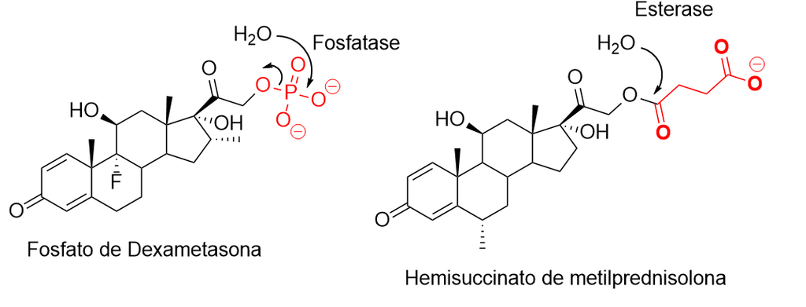

Figure 3.9: Estruturas do Fosfato de Dexametasona e do Hemisuccinato de Metilprednisolona, pró-fármacos hidrossolúveis de corticosteroides. Ambas as estruturas são ésteres projetados para serem hidrolisados enzimaticamente no organismo – o fosfato de dexametasona por uma fosfatase e o hemisuccinato de metilprednisolona por uma esterase – liberando as formas ativas dos corticosteroides (dexametasona e metilprednisolona, respectivamente) para ação terapêutica rápida, especialmente em situações de emergência.

Esses ésteres solúveis funcionam como pró-fármacos, que são projetados para hidrolisar rapidamente no corpo para formar os álcoois corticoides livres, que são as formas ativas. A ativação do fosfato de dexametasona, por exemplo, é muito rápida; o éster de fosfato hidrolisa rapidamente após a administração intravenosa, apresentando uma meia-vida terminal de cerca de 5 minutos , e as concentrações plasmáticas máximas da dexametasona ativa são atingidas em aproximadamente 10 minutos. Na escolha do éster, os fosfatos de glicocorticoides demonstraram ser mais estáveis in vitro do que os hemisuccinatos e também foi relatado que liberam os álcoois livres mais rapidamente. Estudos clínicos validaram a segurança dessa abordagem, concluindo que doses intravenosas únicas de até 30 mg/kg de succinato de sódio de metilprednisolona são seguras e não produzem efeitos sistêmicos graves.

## 3.7 Uso não sistêmico de corticosteroides

O uso de corticosteroides não sistêmicos (como cremes, sprays e injeções locais) tem como principal vantagem a redução dos efeitos colaterais sistêmicos, já que seu efeito se concentra no local de aplicação e diminui a exposição do restante do organismo. Isso permite tratar diretamente tecidos afetados com doses menores e controle mais preciso da intensidade terapêutica. Por outro lado, há risco de efeitos adversos locais, como atrofia, estrias, infecções secundárias e reações na pele, assim como complicações específicas conforme a via escolhida. A absorção limitada pode ser um limite para tratar condições que exigem amplo controle inflamatório. Já os corticosteroides sistêmicos apresentam amplo potencial de efeitos colaterais generalizados como diabetes, hipertensão, supressão adrenal e risco aumentado de infecções, sendo reservados para situações em que é necessário suprimir a inflamação em todo o corpo. Portanto, a decisão entre proporcionar o efeito localizado ou sistêmico exige avaliação cuidadosa do risco-benefício conforme a doença, extensão da inflamação e resposta desejada.

No tratamento da asma, o uso de corticosteroides inalatórios que não são **antefármacos** apresenta limitações importantes quanto à segurança, especialmente em terapia prolongada. Essas moléculas ativas convencionais permanecem biologicamente disponíveis após atingirem a circulação sistêmica. Ao contrário dos **antefármacos** — que se tornam inativos rapidamente após exercerem efeito local — os corticosteroides tradicionais podem se acumular e provocar toxicidade sistêmica, o que limita a margem terapêutica para asma persistente e pode prejudicar o perfil de segurança em pacientes vulneráveis, exigindo monitoramento rigoroso durante o uso crônico.

O uso oftálmico de corticosteroides, especialmente em colírios e aplicações locais crônicas, pode levar ao aumento da PIO e ao desenvolvimento de glaucoma induzido por corticoide, além de promover catarata subcapsular posterior mesmo em pacientes jovens. Esses efeitos adversos decorrem da capacidade dos corticosteroides de alterar o metabolismo local do humor aquoso e modificar proteínas do cristalino, o que favorece dano irreversível ao nervo óptico e opacificação visual progressiva. Fármacos oftalmológicos mais modernos, são projetados **antefármacos** ou com rápida inativação local, permitindo ação anti-inflamatória ocular potente, porém com risco sistêmico e local reduzido, minimizando assim a chance de desenvolver glaucoma ou catarata cortisônica nos tratamentos prolongados em oftalmologia.

## 3.8 Da Terapia Sistêmica à Aplicação Tópica: O Desafio da Barreira Cutânea

A transição dos corticosteroides do uso sistêmico para o tópico apresentou um desafio formidável: a barreira cutânea. Enquanto a cortisona era ineficaz topicamente, a hidrocortisona demonstrou atividade anti-inflamatória local significativa, abrindo caminho para o tratamento dermatológico. No entanto, simplesmente aplicar os análogos sistêmicos mais potentes (como os fluorados em C-9, que aumentavam a potência, mas também os efeitos colaterais eletrolíticos) na pele muitas vezes resultava em eficácia decepcionante. Tornou-se evidente que, além da potência intrínseca, a molécula precisava possuir propriedades físico-químicas adequadas – como solubilidade e coeficiente de partição – para permear o estrato córneo e alcançar os sítios de ação nas camadas viáveis da pele, idealmente exercendo efeito local com mínima absorção sistêmica Figure 3.10.

A química farmacêutica então se voltou para modificações que otimizassem a penetração cutânea e a atividade local. Uma descoberta crucial e por acaso foi a introdução do grupo **acetonido cíclico nas posições C-16α, 17α**. Originalmente utilizado para facilitar a separação de misturas sintéticas, descobriu-se que o grupo acetonido não apenas reduzia drasticamente os efeitos indesejados de retenção de eletrólitos associados à fluoração em C-6α e/ou C-9α, mas também conferia propriedades físico-químicas que **aumentavam dramaticamente a penetrabilidade cutânea** (resultando em atividade tópica 10 vezes maior que o composto parental, sem aumento da atividade sistêmica) Figure 3.10.

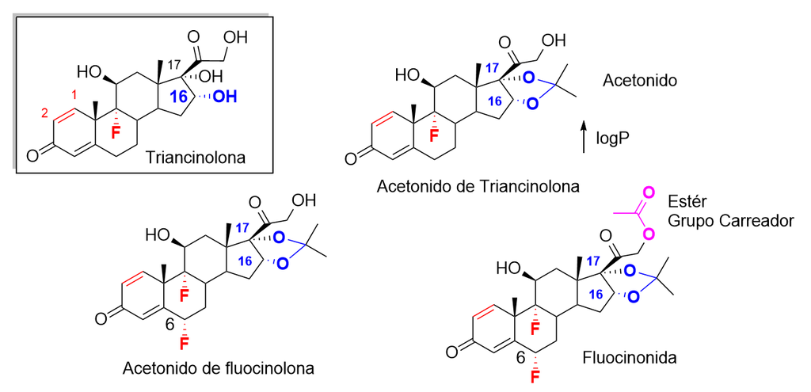

Figure 3.10: Estruturas químicas de triancinolona, acetonido de triancinolona, fluocinonida e acetonido de fluocinolona, destacando as posições 16, 17 (formação do acetonido) e o átomo de flúor em C9 (e C6 na fluocinolona/fluocinonida). A modificação acetonídea aumenta a lipofilicidade (logP) e potencializa o efeito tópico, enquanto grupamentos éster podem modular o perfil farmacocinético local e reduzir a toxicidade sistêmica, de acordo com dados estruturais e farmacológicos descritos para corticosteroides tópicos de alta potência.

Outra modificação valiosa foi a **esterificação da hidroxila em C-21**, comumente com um grupo acetato. Esses ésteres aumentavam a lipofilicidade, otimizando a absorção percutânea, e eram mais resistentes à hidrólise metabólica na pele, proporcionando atividade prolongada. A combinação dessas modificações específicas para uso tópico com aquelas já conhecidas por aumentar a potência (como a dupla ligação $\Delta^1$, fluoração em C-6α e C-9α) levou a uma geração de corticosteroides tópicos progressivamente mais potentes e eficazes, como a triancinolona acetonido, fluocinolona acetonido e a fluocinonida.

## 3.9 Pró-fármacos com grupo carreador: Uma Estratégia Promissora

Uma abordagem proeminente é o design de pró-fármacos, que são derivados quimicamente modificados do fármaco ativo, inativos ou menos ativos *in vitro*, projetados para liberar o GC ativo *in vivo* através de transformações enzimáticas ou não enzimáticas.

O design de um pró-fármaco de GC envolve três componentes essenciais: o GC ativo (ingrediente ativo), um ligante (linker) clivável que conecta o GC a um grupo funcional, e o próprio grupo funcional, que confere propriedades adicionais como direcionamento. O hidroxila na posição 21 dos GCs é frequentemente usada para criar pró-fármacos do tipo éster Figure 3.10. A posição 17 também pode utilizado em concomitantemente para melhor otimização. Exemplos são dipropionato de betametasona e beclometasona ou valerato de betametasona Figure 3.11.

[figure not shown]

Figure 3.11: Representação estrutural dos ésteres de corticosteroides tópicos: dipropionato de betametasona e dipropionato de betclometasona (modificados nas posições 17 e/ou 21), ressaltando a presença de grupos carreadores (ésteres de ácido propiónico) que aumentam a lipofilicidade e promovem retenção cutânea. Essas modificações otimizam o perfil de ação tópica e minimizam absorção sistêmica, características fundamentadas em estudos de farmacologia de corticosteroides tópicos atuais.

### 3.9.1 Ésters sem hidroxila em C-21

O furoato de mometasona (FM) é classificado como um corticoide inalado/intranasal (ICS) de segunda geração, caracterizado pela sua alta potência local e baixa biodisponibilidade sistêmica (<1%). A sua elevada eficácia deriva da sua afinidade extremamente alta pelo receptor de glicocorticoide (RRA ≈ 2200, comparado a 100 para dexametasona), uma das mais altas entre os ICS. Semelhante a outros corticoides esterificados, presume-se que a porção furoato aumente a lipofilicidade do composto, promovendo a retenção no tecido pulmonar ou na mucosa nasal após a administração tópica, o que contribui para a sua ação prolongada. Embora a biodisponibilidade sistémica do FM inalterado seja muito baixa, a presença destes metabolitos/produtos de degradação com atividade residual levanta questões sobre a sua potencial contribuição para efeitos sistémicos, como a supressão do eixo HPA observada em alguns estudos clínicos, especialmente com doses elevadas Figure 3.12.

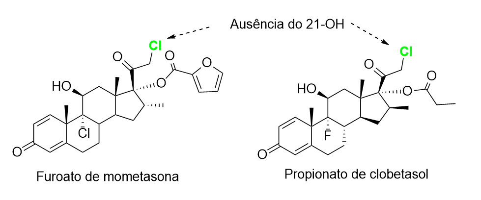

Figure 3.12: Estruturas químicas do Furoato de Mometasona (esquerda) e Propionato de Clobetasol (direita). As setas tracejadas indicam a ausência do grupo hidroxila (OH) na posição C21 em ambas as moléculas, destacando a presença de um átomo de cloro (Cl) nesta posição em seu lugar. Ambas as moléculas mantêm alta atividade glicocorticoide devido a outras modificações estruturais potentes.

O propionato de clobetasol é reconhecido como um dos corticosteroides tópicos mais potentes disponíveis para uso dermatológico, geralmente formulado a 0,05% em creme ou pomada. Embora destinado à ação local na pele, a sua alta potência está associada a um risco significativo de absorção percutânea e consequentes efeitos sistêmicos, especialmente quando usado em grandes áreas, por longos períodos, ou sobre pele danificada ou atrofiada. Estudos demonstraram que a aplicação tópica de quantidades superiores a 50 g por semana pode levar à supressão do eixo hipotálamo-hipófise-adrenal (HPA), tanto em voluntários saudáveis quanto em pacientes. Em quantidades maiores (acima de 100 g/semana), foram observadas supressão profunda do eixo HPA e características da síndrome de Cushing iatrogênica. Portanto, ao contrário de alguns corticosteroides inalados/intranasais mais recentes projetados especificamente para minimizar a biodisponibilidade sistêmica, o uso tópico de clobetasol exige cautela e limitação da quantidade total aplicada (recomendado <50 g/semana) para mitigar o risco de efeitos adversos sistêmicos. A sua lipofilicidade, que contribui para a penetração cutânea e retenção local, também facilita a sua absorção sistêmica.

Uma característica estrutural notável tanto do propionato de clobetasol quanto do furoato de mometasona é a ausência do grupo hidroxila (OH) na posição C21, que é frequentemente considerado importante para a atividade glicocorticoide clássica e ligação ao receptor. Em vez disso, ambos possuem um átomo de cloro (Cl) nesta posição (ligado ao carbono 21). Apesar desta modificação, ambos os compostos exibem atividade glicocorticoide excepcionalmente alta. Isso é explicado pelas outras modificações potentes em suas estruturas moleculares que compensam a ausência do 21-OH e aumentam drasticamente a afinidade de ligação ao receptor de glicocorticoide (GR) e a potência intrínseca.

## 3.10 Ação Local com Inativação Sistêmica (“Antefármacos”)

A lógica de minimizar efeitos sistêmicos através do design molecular está presente. O conceito de antefármacos (ou “soft drug”) refere-se a um composto ativo localmente que é projetado para sofrer uma rápida e previsível inativação metabólica ao atingir a circulação sistêmica. Isso difere do pró-fármaco tradicional, que é inativo e requer ativação.

### 3.10.1 Ciclesonida e Budesonida

A ciclesonida foi especificamente desenhado como um “pro-soft drug” ou “pró-antefármaco” para maximizar a ação local nos pulmões e minimizar os efeitos colaterais sistémicos e orofaríngeos frequentemente associados aos corticoides inalados (ICS). Administrado na forma de um pró-fármaco inativo, o ciclesonida possui baixa afinidade pelos recetores de glicocorticoides. No entanto, após a inalação e deposição pulmonar, ele é eficientemente convertido no seu metabolito ativo, o desisobutiril-ciclesonida (des-CIC), por esterases presentes nas células epiteliais brônquicas. Este metabolito ativo, des-CIC, demonstra uma afinidade muito elevada pelos recetores de glicocorticoides, cerca de 100 vezes superior à do ciclesonida original, garantindo uma potente ação anti-inflamatória localmente nos pulmões. Além disso, o des-CIC forma conjugados reversíveis de ésteres de ácidos graxos altamente lipofílicos (como o des-CIColeato) dentro do tecido pulmonar. Estes conjugados funcionam como um reservatório local, libertando gradualmente o des-CIC ativo e prolongando significativamente a sua residência e duração de ação nos pulmões, permitindo uma administração em dose única diária. A exposição sistémica é minimizada por uma combinação de fatores: biodisponibilidade oral muito baixa (<1%) devido à baixa deposição oral e extenso metabolismo de primeira passagem hepático, ligação extremamente elevada às proteínas plasmáticas (~99% tanto para o ciclesonida como para o des-CIC), o que limita a fração livre disponível sistemicamente , e uma rápida depuração sistémica do metabolito ativo.

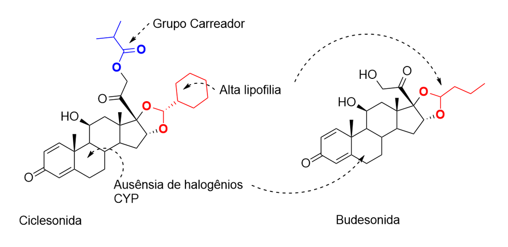

Figure 3.13: Estruturas da ciclenosida e budesonida, dois corticosteroides inalados de alta lipofilia. A ciclenosida exibe grupo carreador (éster), promovendo efeito antefármaco e metabolismo rápido após ação local, além de ausência de halogênios — característica que reduz o potencial de inibição de CYP450. A budesonida, também lipofílica tem potência anti-inflamatória e curta permanência sistêmica, favorecendo segurança em uso prolongado conforme evidências da literatura farmacológica de corticosteróides inalados modernos.

A budesonida, outro corticoide inalado, também utiliza um mecanismo de retenção local para prolongar a sua ação nos pulmões e limitar a exposição sistémica. Semelhante ao metabolito ativo do ciclesonida, a budesonida sofre uma conjugação reversível com ácidos graxos (esterificação) dentro das células das vias aéreas. Estes ésteres de ácidos gordos da budesonida funcionam como um depósito intracelular inativo do fármaco. A partir deste depósito, a budesonida ativa é libertada lentamente por hidrólise, prolongando assim a sua presença e atividade anti-inflamatória diretamente no tecido pulmonar. Este mecanismo de retenção local contribui para a eficácia da budesonida no controlo da inflamação das vias aéreas. Adicionalmente, a budesonida que é engolida (a fração depositada na orofaringe e não removida) sofre um extenso metabolismo de primeira passagem no fígado, o que resulta numa baixa biodisponibilidade sistémica a partir da absorção gastrointestinal (cerca de 11%). A sua elevada ligação às proteínas plasmáticas (88%) também contribui para limitar a quantidade de fármaco livre na circulação sistémica. Estes fatores, combinados com o mecanismo de retenção pulmonar por esterificação, ajudam a otimizar o índice terapêutico da budesonida inalada.

(https://www.jpharmsci.org/article/S0022-3549(16)41415-2/fulltext)

### 3.10.2 Maximizando a Ação Local e Minimizando Efeitos Sistêmicos

O propionato de fluticasona (PF) é um glicocorticoide tópico potente desenhado para maximizar a eficácia terapêutica no local de aplicação — seja a mucosa nasal ou as vias aéreas pulmonares — enquanto minimiza os efeitos colaterais sistêmicos indesejados. Esta seletividade é alcançada através de uma combinação estratégica de propriedades farmacocinéticas e metabólicas. A porção da dose administrada por via intranasal ou inalatória que é inevitavelmente deglutida contribui muito pouco para os efeitos sistêmicos devido à sua biodisponibilidade oral virtualmente zero. Estudos demonstram que, após a administração oral, o PF não é detectado de forma inalterada no plasma nas primeiras horas, indicando um metabolismo extensivo.

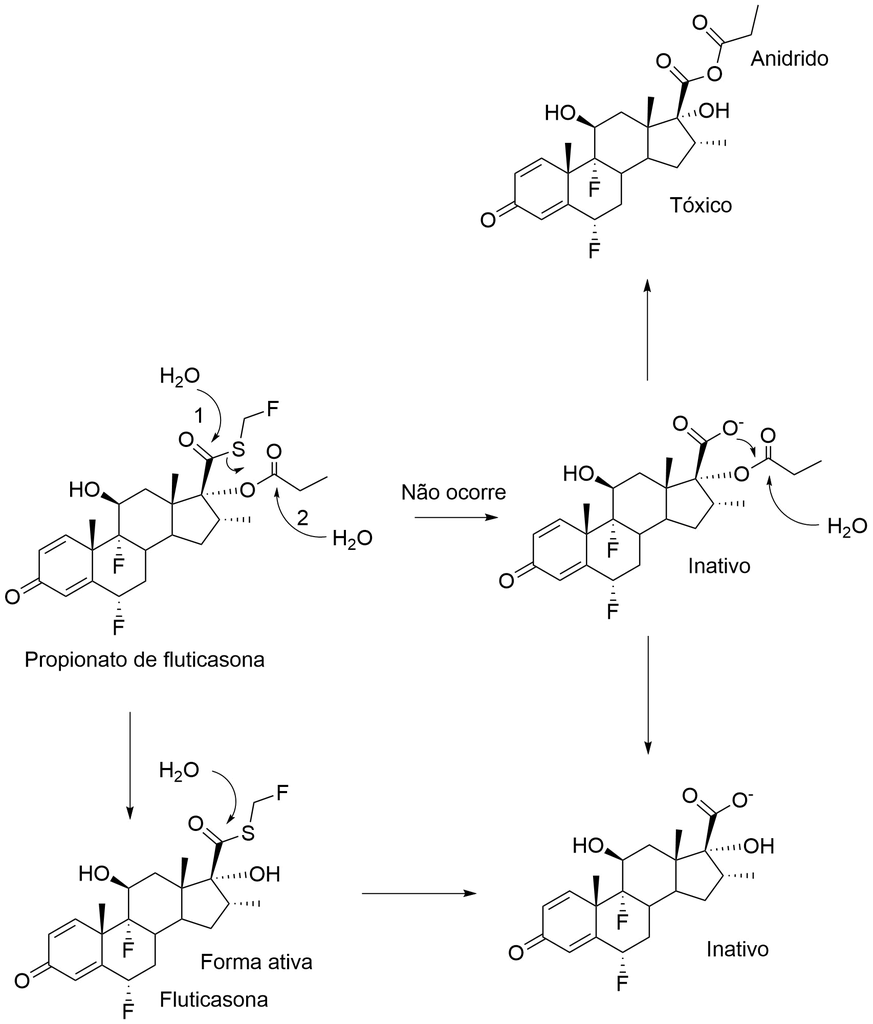

Figure 3.14: Mecanismo de ativação e inativação do propionato de fluticasona, um corticosteroide inalado antedrug: o éster propionato é rapidamente hidrolisado após aplicação, primeiro dando origem à fluticasona ativa (com grupo hidroxila em C17) e, em seguida, a metabólitos inativos por hidrólise adicional. Essa estratégia favorece efeito local potente nas vias aéreas e minimiza exposição e toxicidade sistêmica, alinhada ao conceito de segurança farmacológica para antedrugs modernos. **A rota de quebra da pelo ataque em 17 primeiro é a preferencial já que pode haver uma reação do ácido carboxílico com o estér adjacente.**

## 3.11 Corticoides para uso oftálmico

Os corticosteroides são pilares no tratamento de condições inflamatórias oculares devido à sua potente atividade anti-inflamatória. No entanto, seu uso, especialmente o tópico e prolongado, está associado a efeitos colaterais significativos que limitam sua segurança clínica. Os dois problemas farmacológicos mais importantes são a **elevação da pressão intraocular** (PIO), conhecida como **hipertensão ocular induzida por glicocorticoide (GIOHT)**, que pode levar ao **glaucoma**, e a formação de **catarata**. Corticosteroides mais antigos e potentes, como a dexametasona e a prednisolona, são particularmente conhecidos por terem maior propensão a elevar a PIO. O mecanismo subjacente à elevação da PIO envolve alterações fisiológicas na principal via de drenagem do humor aquoso, a malha trabecular, levando ao aumento da resistência ao fluxo. Essa limitação de segurança representa um desafio clínico, especialmente para pacientes que necessitam de tratamento crônico ou que já possuem fatores de risco para glaucoma.

Para a administração oftálmica, a solubilidade e a lipofilicidade dos ésteres também desempenham um papel crucial na penetração e duração do efeito. Formas mais lipofílicas, como os ésteres acetato (ex: acetato de prednisolona), apresentam maior penetração corneana em comparação com formas mais hidrofílicas, como os fosfatos (ex: fosfato de dexametasona ou prednisolona). Essa maior penetração pode resultar em maior eficácia anti-inflamatória no segmento anterior, mesmo que a potência intrínseca do fármaco base seja menor. No entanto, a necessidade de formulações aquosas para colírios ou injeções ainda favorece o uso de ésteres solúveis em muitas situações.

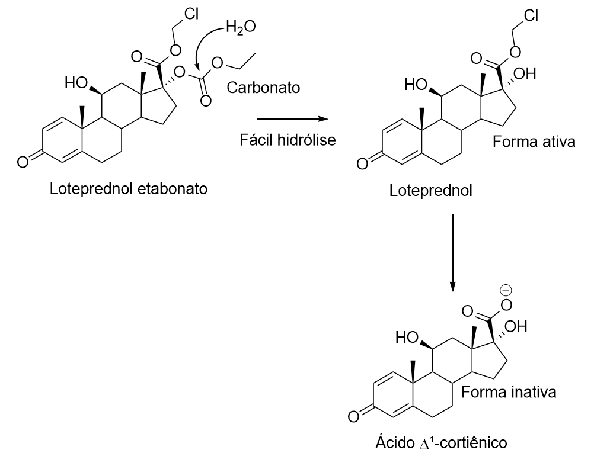

Figure 3.15: Mecanismo de ativação e inativação metabólica do Loteprednol Etabonato (LE), um exemplo de “soft drug” ou antefármaco. O LE, um pró-antefármaco, é inicialmente hidrolisado para formar a forma ativa (Loteprednol) que exerce a atividade anti-inflamatória. Subsequentemente, o Loteprednol sofre rápida hidrólise previsível para formar o Ácido Δ¹-cortiênico, um metabólito inativo. Essa rápida e controlada inativação local minimiza os efeitos colaterais sistêmicos e oculares, como a elevação da pressão intraocular, conferindo um perfil de segurança aprimorado.

Essa rápida biotransformação em metabólitos inativos diretamente nos tecidos oculares minimiza a exposição sistêmica e, crucialmente, reduz a propensão a causar efeitos colaterais locais como a elevação da PIO. Estudos clínicos comparativos demonstraram consistentemente que o lotepredinol tem uma incidência significativamente menor de elevações clinicamente significativas da PIO (≥10 mmHg) em comparação com a prednisolona acetato e a dexametasona, tanto em uso de curto quanto de longo prazo. Esse perfil de segurança favorável é observado inclusive em pacientes conhecidos como “respondedores a esteroides”, que são particularmente suscetíveis à GIOHT. O desenvolvimento de “soft drugs” como o loteprednol etabonato representa, portanto, um avanço importante no planejamento de fármacos oftálmicos, buscando otimizar a relação entre eficácia terapêutica e segurança no tratamento da inflamação ocular.

## 3.12 Considerações finais.

Este capítulo analisou a evolução da química farmacêutica dos corticosteroides (GCs), agentes terapêuticos cruciais no tratamento de distúrbios inflamatórios e na supressão imunológica. O mecanismo central de sua eficácia é a ação nuclear, onde o complexo fármaco-receptor opera principalmente pela transrepressão de genes pró-inflamatórios (como citocinas e COX-2). A força motriz para o desenvolvimento de análogos sintéticos foi a necessidade de dissociar a potente atividade anti-inflamatória dos graves efeitos adversos metabólicos e da atividade mineralocorticoide indesejada, os quais são inerentes ao uso prolongado do cortisol e à supressão do eixo Hipotálamo-Pituitária-Adrenal (HPA).

O primeiro grande avanço estrutural foi a introdução da dupla ligação $\Delta^1$ (C1-C2), resultando na Prednisolona, que aumentou a potência glicocorticoide em três a cinco vezes. Contudo, a verdadeira revolução foi a síntese da Dexametasona, que combinou a fluoração em C-9 (α-F) com a metilação em C-16 (α-metil), alcançando uma potência extrema (25 a 80 vezes maior que o cortisol) e, crucialmente, atividade mineralocorticoide nula, atingindo a dissociação terapêutica desejada.

Na busca por um índice terapêutico otimizado, a química farmacêutica moderna avançou em direção à especificidade local e segurança. Estratégias como a conversão em pró-fármacos hidrossolúveis (fosfatos ou hemisuccinatos) permitiram a administração intravenosa rápida em emergências. Para uso tópico (dermatológico e inalatório), modificações como o grupo acetonido cíclico (C-16 $\alpha$, 17 $\alpha$) foram essenciais para aumentar a lipofilicidade e a penetração cutânea. Mais recentemente, o conceito de antefármacos (soft drugs) se estabeleceu, como exemplificado pelo Propionato de Fluticasona ou Loteprednol Etabonato. Esses compostos são desenhados para serem ativos no local de aplicação, mas sofrem rápida e previsível inativação metabólica ao atingir a circulação sistêmica, minimizando assim o risco de toxicidades sistêmicas (como a supressão do HPA) e efeitos locais indesejados (como a hipertensão ocular induzida por glicocorticoide ou GIOHT), redefinindo a segurança no tratamento crônico de doenças inflamatórias.